# Project02_wineQuality by Adam

# 各变量之间相关性查看1

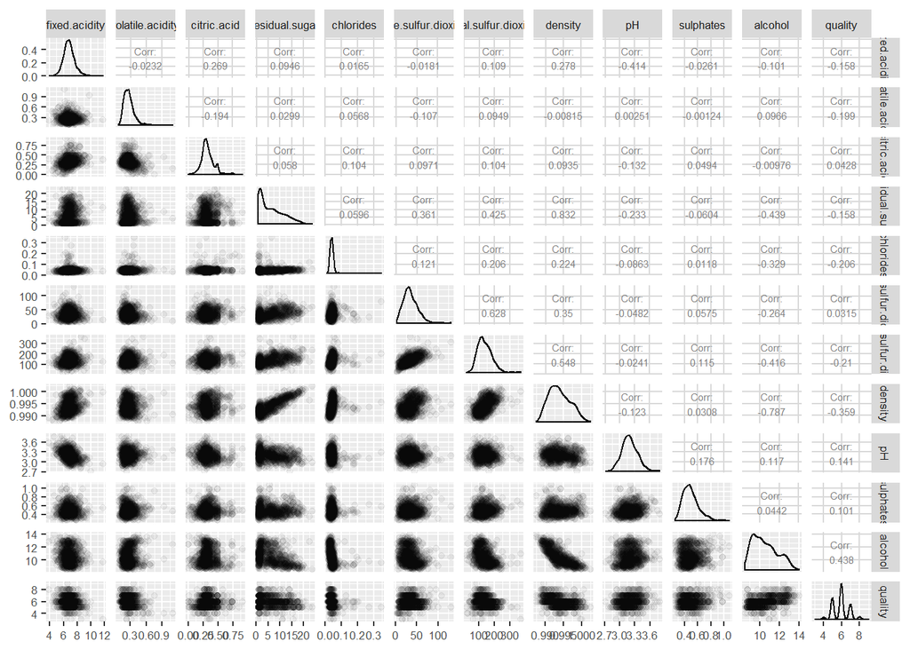

# 各变量之间相关性查看2

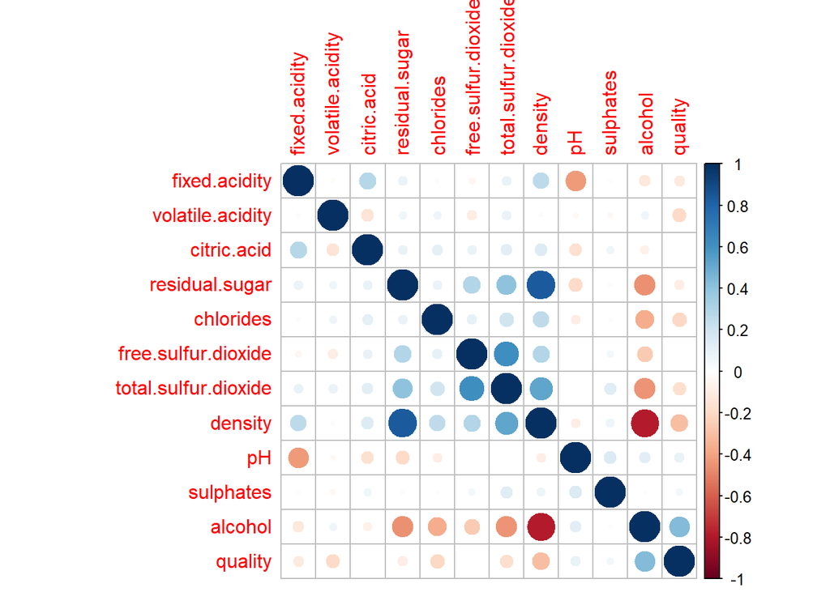

# 单变量绘图选择

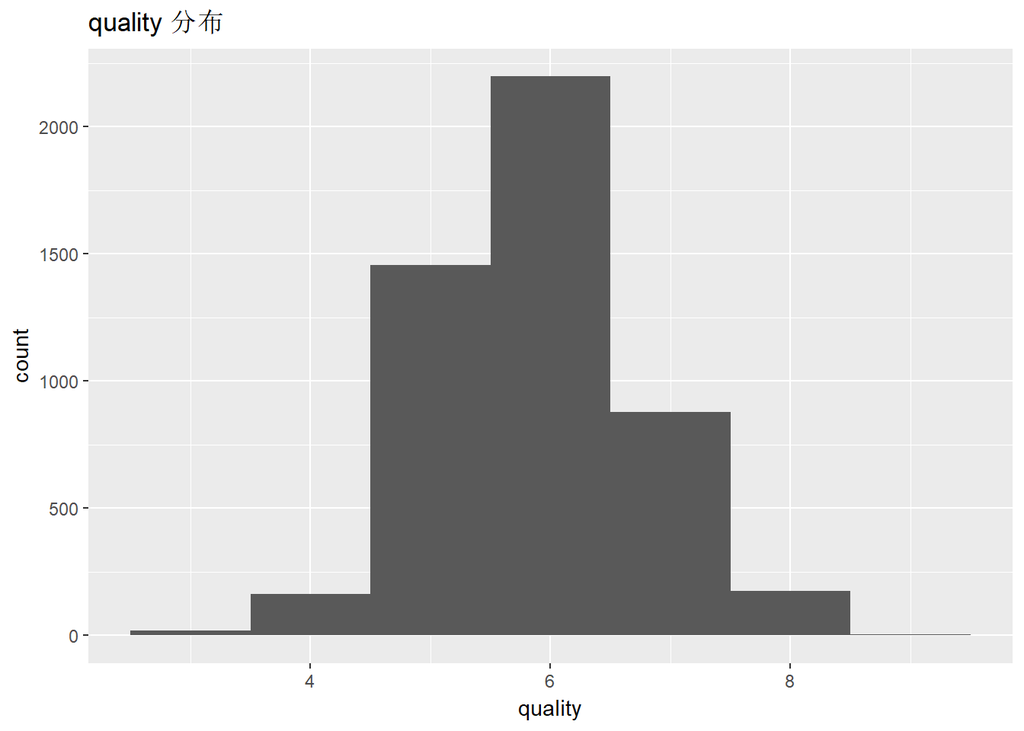

- quality 呈正态分布

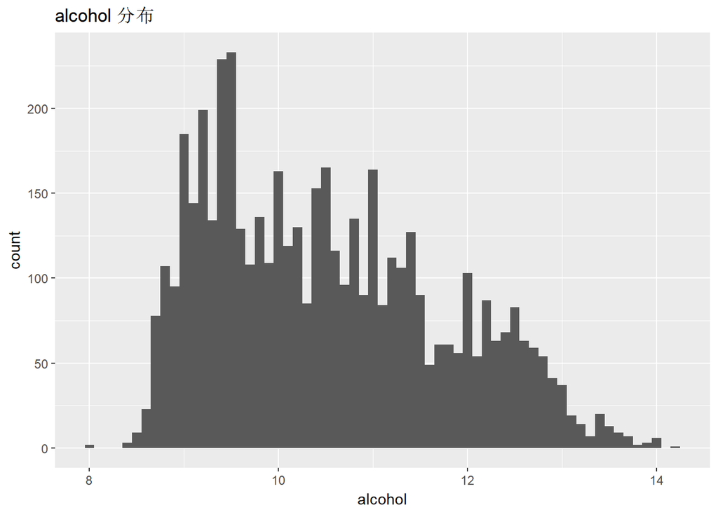

- alcohol 总体分布在9到11.5左右

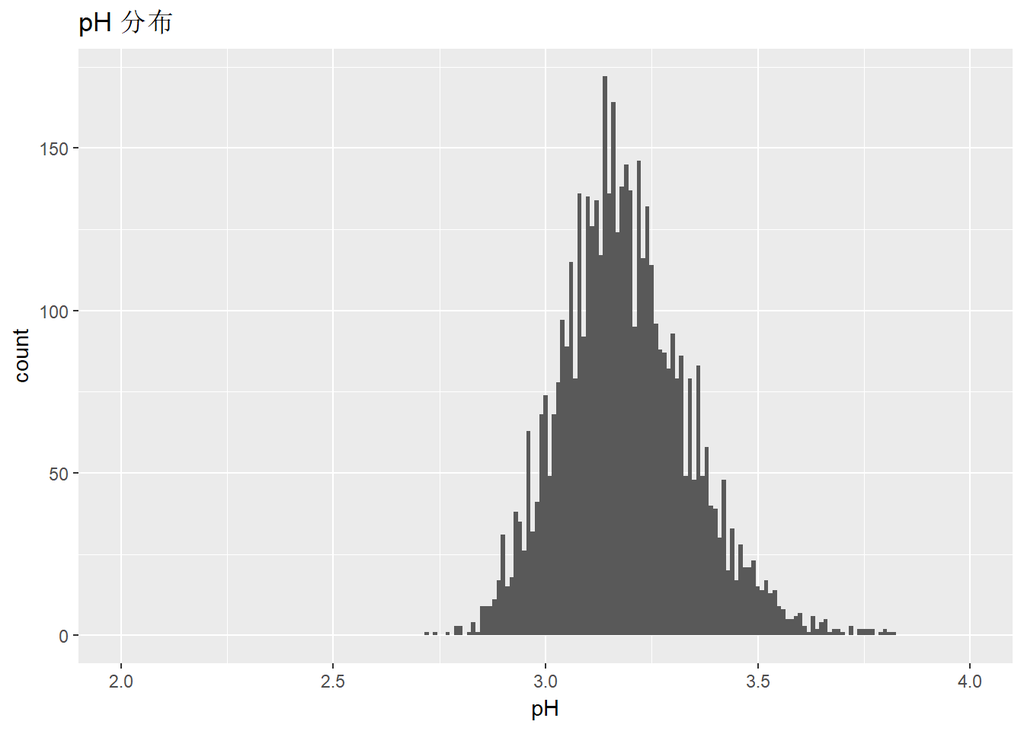

- pH 呈正态分布

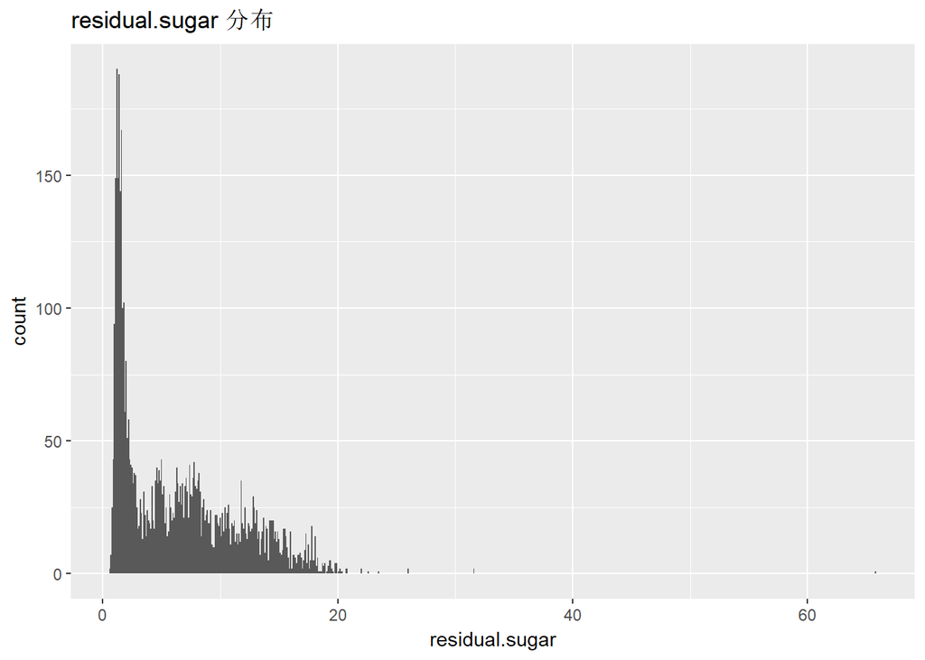

- 多数 residual.sugar 并不高

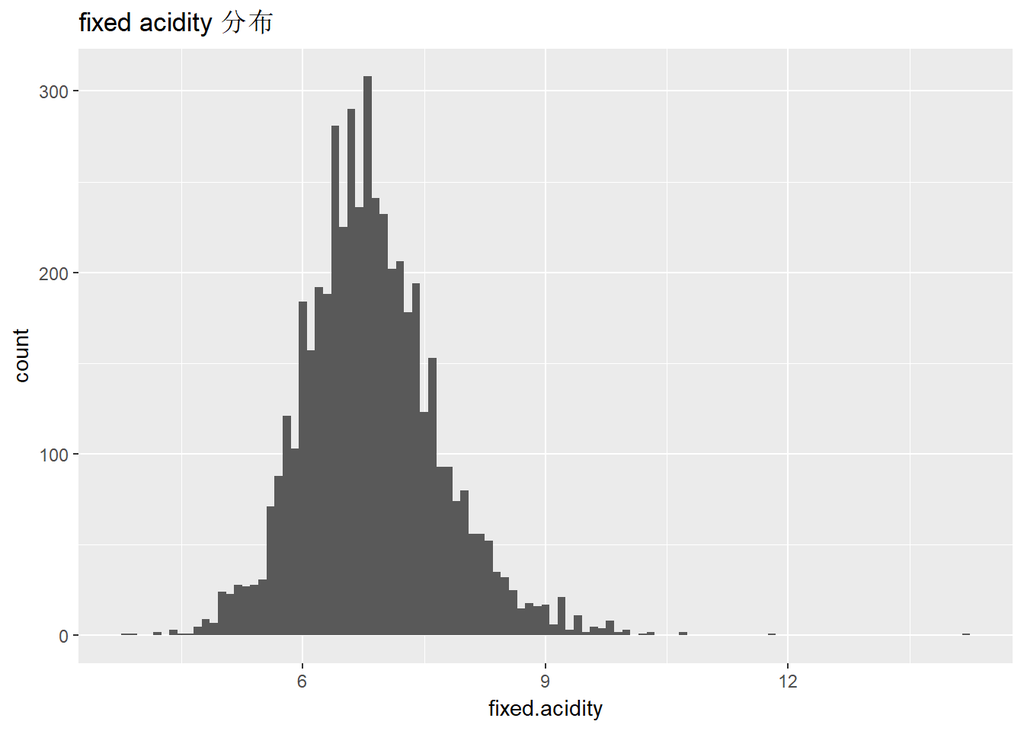

- fixed.acidity 呈正态分布

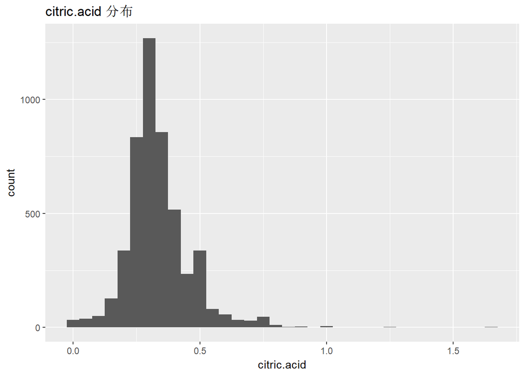

- citric.acid 呈正态分布

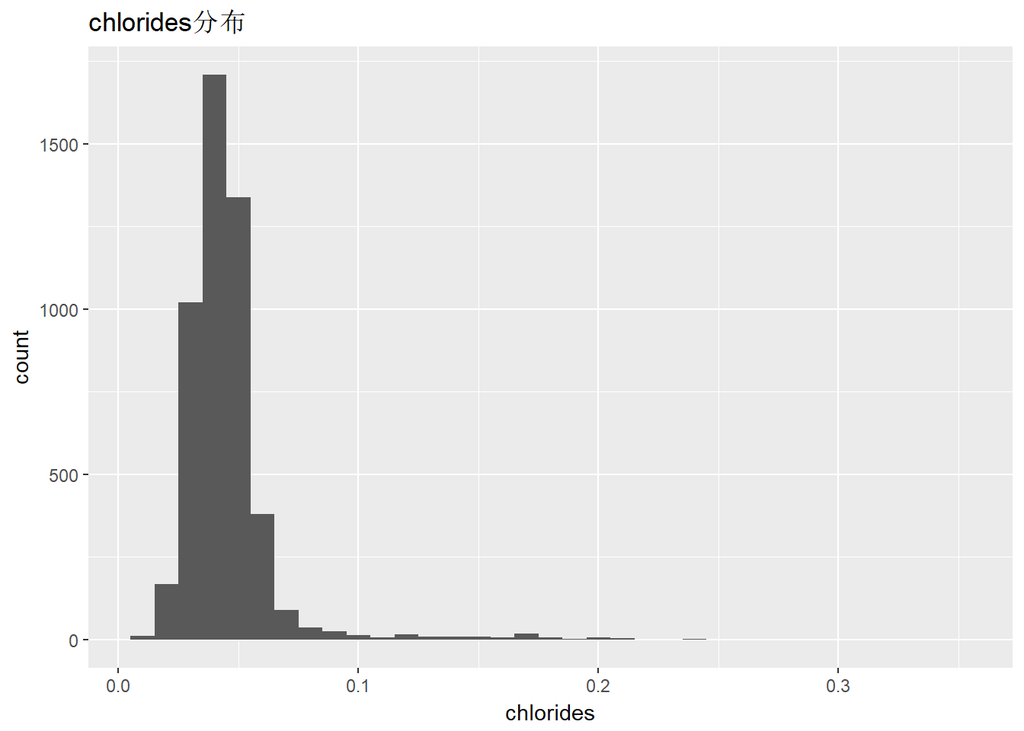

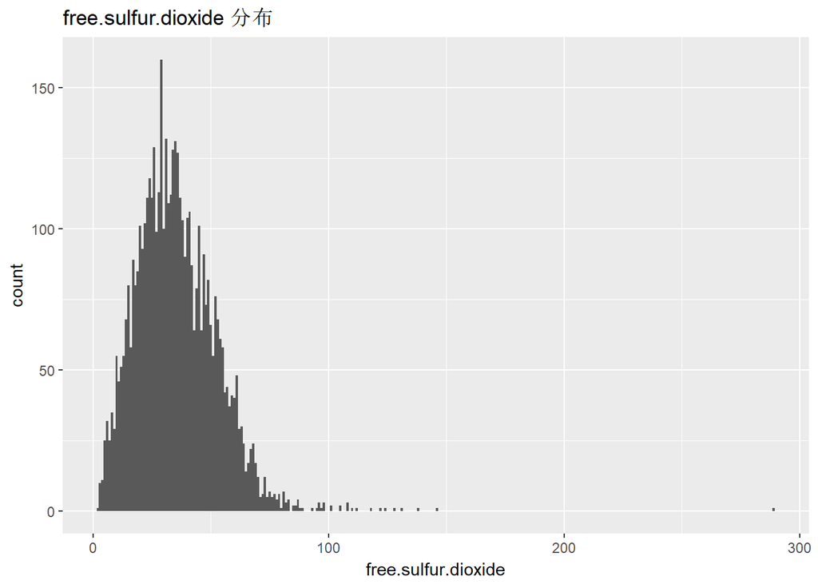

- free.sulfur.dioxide 呈正态分布，有少量异常值

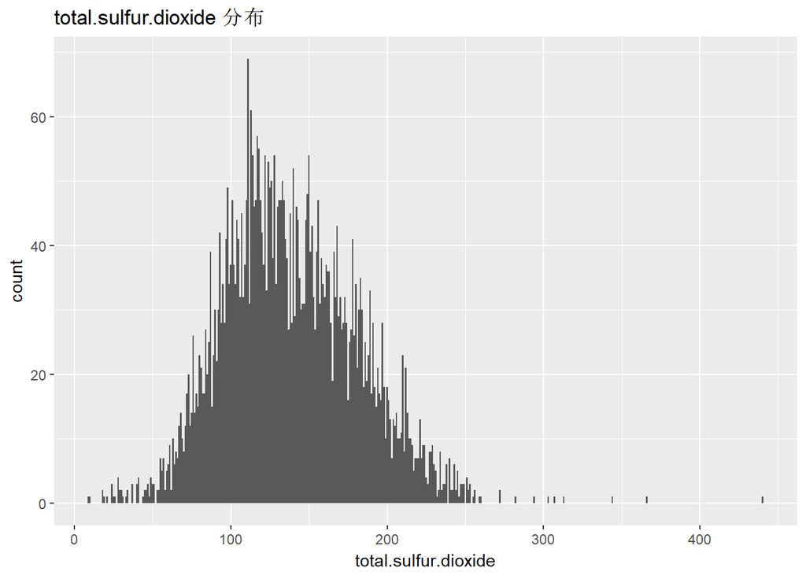

- total.sulfur.dioxide 呈正态分布，异常值并不多

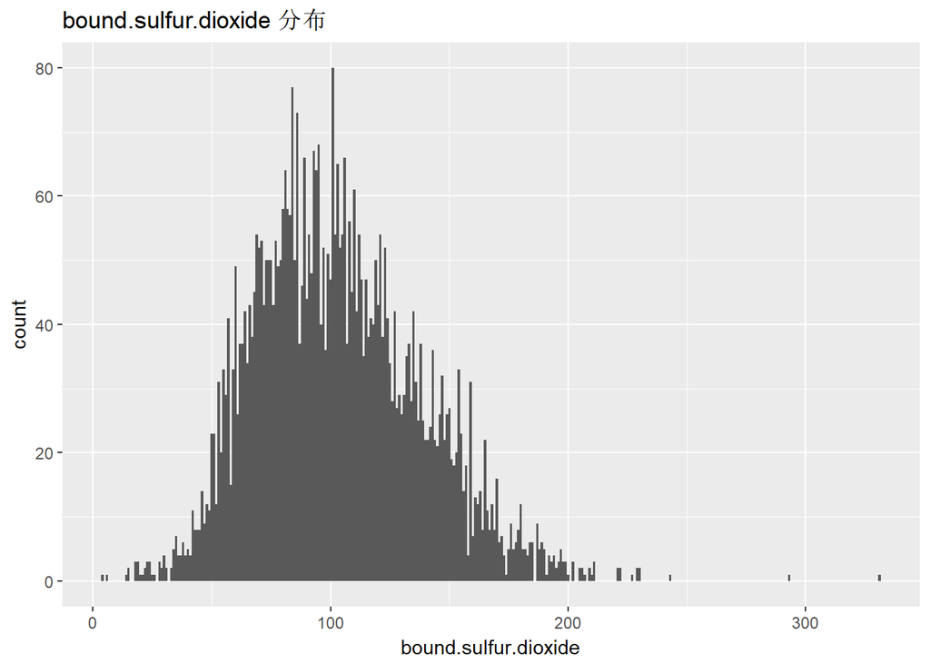

- bound.sulfur.dioxide 呈正态分布

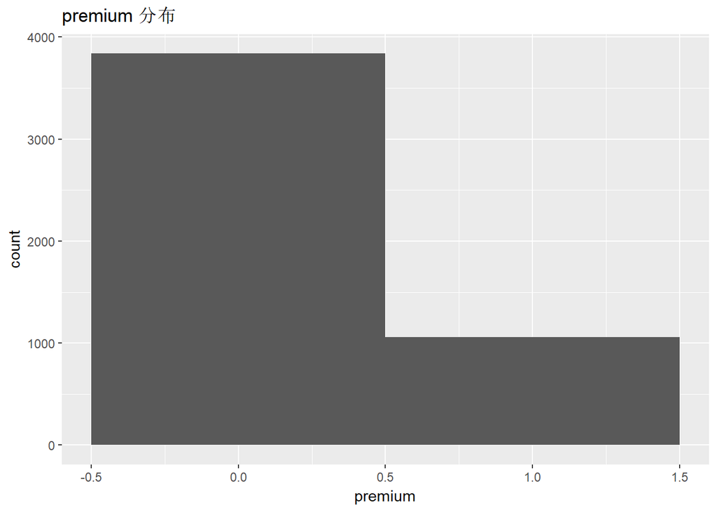

- 高品质 premium （quality 为7,8,9）占少量，约为普通酒的四分之一

# 单变量分析

### 你的数据集结构是什么？

本数据集共有4898个观测值，12个变量，包括 fixed.acidity，volatile.acidity，citric.acid，chlorides， free.sulfur.dioxide， total.sulfur.dioxide，density， pH，sulphates，alcohol，quality

### 你的数据集内感兴趣的主要特性有哪些？

导致白葡萄酒品质的具体指标有哪些

### 你认为数据集内哪些其他特征可以帮助你探索兴趣特点？

对葡萄酒的平衡起着关键性影响的元素，包括：甜度、酸度、果味、酒精以及单宁。

### 根据数据集内已有变量，你是否创建了任何新变量？

根据数据集说明 bound.sulfur.dioxide 加上 free.sulfur.dioxide 等于 total.sulfur.dioxide。 另外添加了高品质 premium （quality 为7,8,9）的变量

### 在已经探究的特性中，是否存在任何异常分布？你是否对数据进行一些操作，如清洁、调整或改变数据的形式？如果是，你为什么会这样做？

未见异常

# 双变量绘图选择

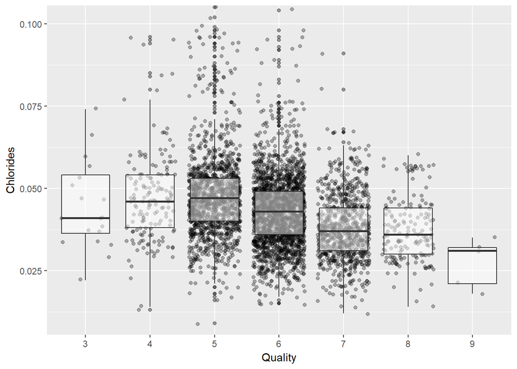

- 大量酒的 chlorides 随着quality 上身而下降

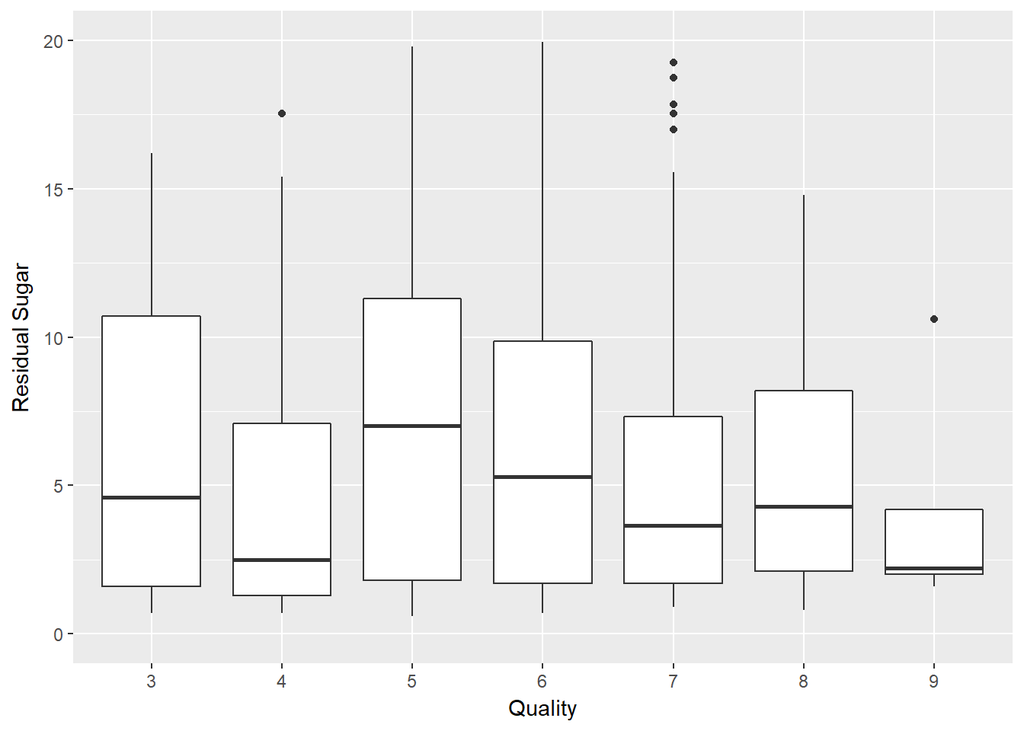

- 此处 residual.sugar 有大量异常值，即便缩小范围，依然没有发现相应规律

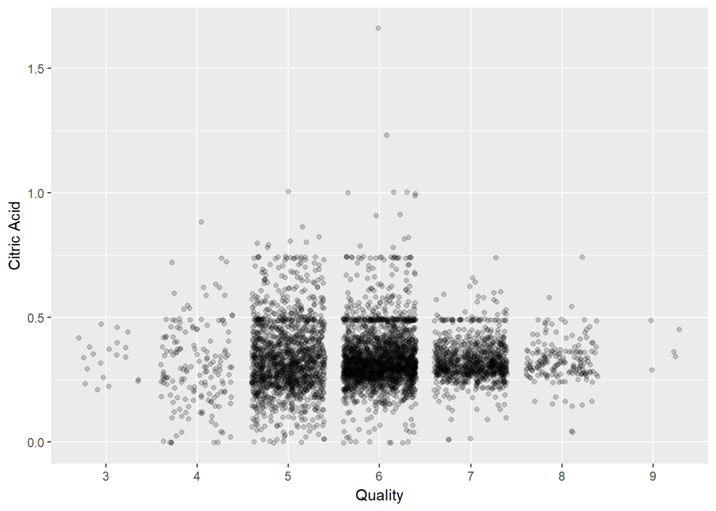

- citric.acid 与quality 无明显关系，在下面分析中会进一步拓展

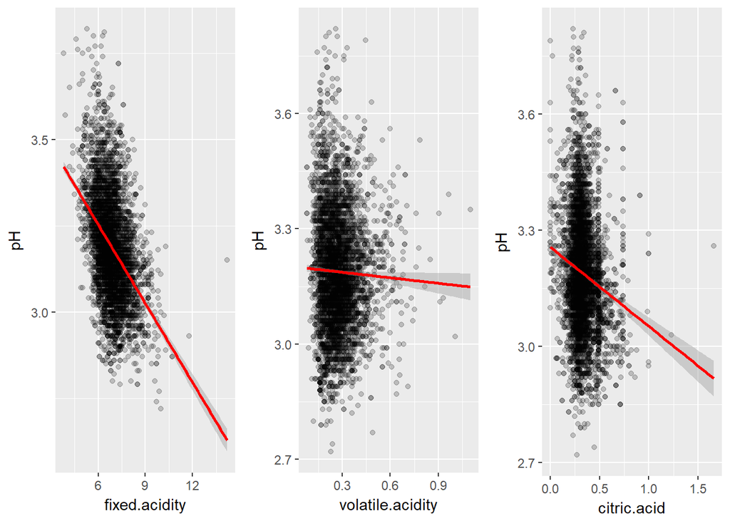

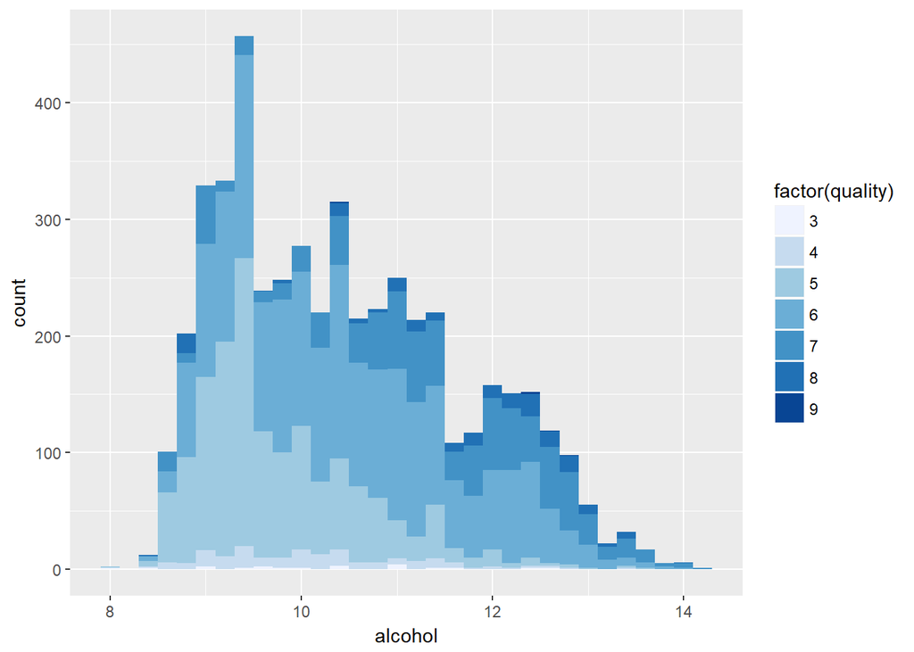

- 随着度数增加，quality 比例增加

```
##
##  Pearson's product-moment correlation
##
## data:  density and alcohol
## t = -87.255, df = 4896, p-value < 2.2e-16
## alternative hypothesis: true correlation is not equal to 0
## 95 percent confidence interval:
##  -0.7908646 -0.7689315
## sample estimates:
##        cor
## -0.7801376
```

```
##
##  Pearson's product-moment correlation
##
## data:  quality and citric.acid
## t = -0.6444, df = 4896, p-value = 0.5193
## alternative hypothesis: true correlation is not equal to 0
## 95 percent confidence interval:
##  -0.03720595  0.01880221
## sample estimates:
##          cor
## -0.009209091
```

```
##
##  Pearson's product-moment correlation
##
## data:  total.sulfur.dioxide and sulphates
## t = 9.5019, df = 4896, p-value < 2.2e-16
## alternative hypothesis: true correlation is not equal to 0
## 95 percent confidence interval:
##  0.1069590 0.1619585
## sample estimates:
##       cor
## 0.1345624
```

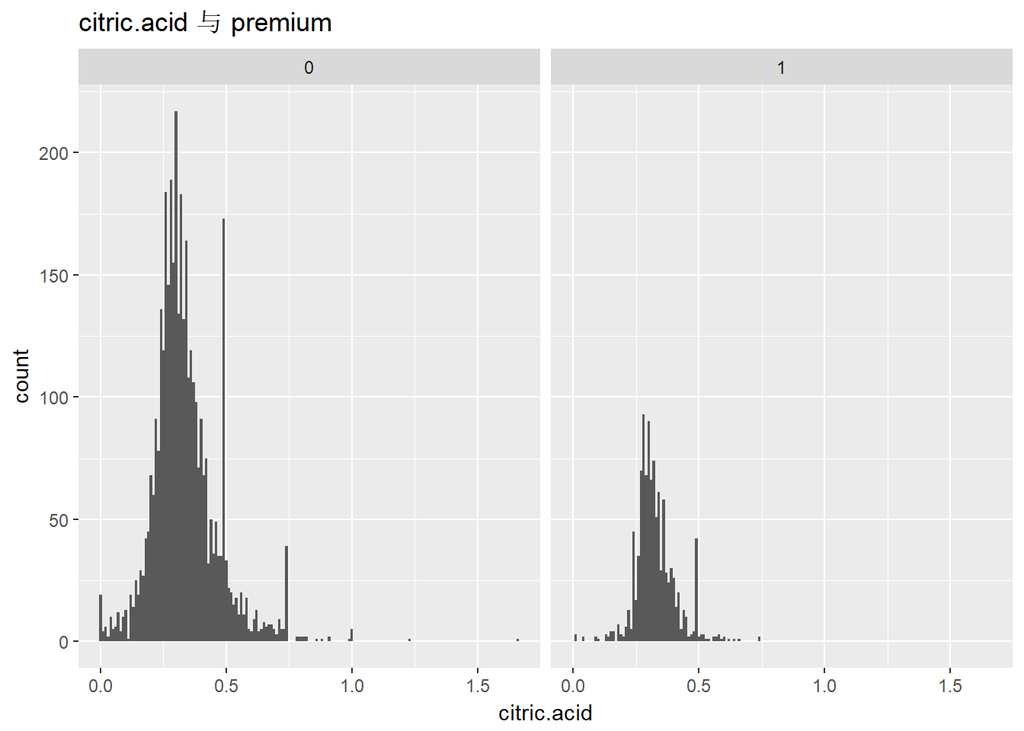

- 绘图也显示柠檬酸与品质并无多大关系，两者分布差不多

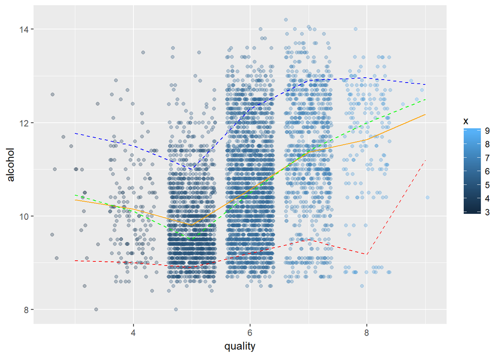

- 按照分批量对 quality 与 alcohol 的关系进行平均可以看到 quality 越高，alcohol 也越高

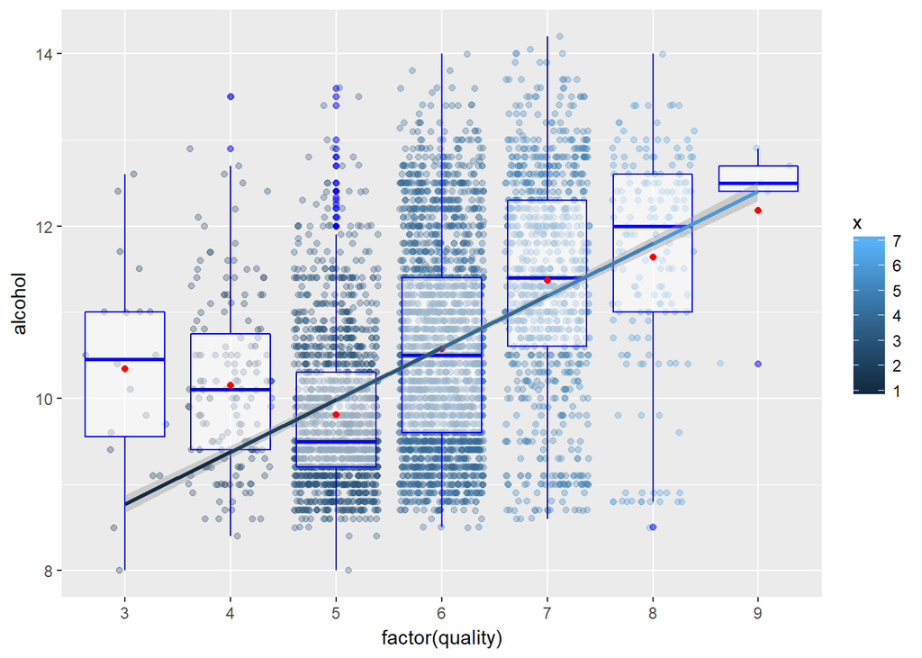

- 在此基础上再描绘一条线性模型，可以更直观的看到以上关系

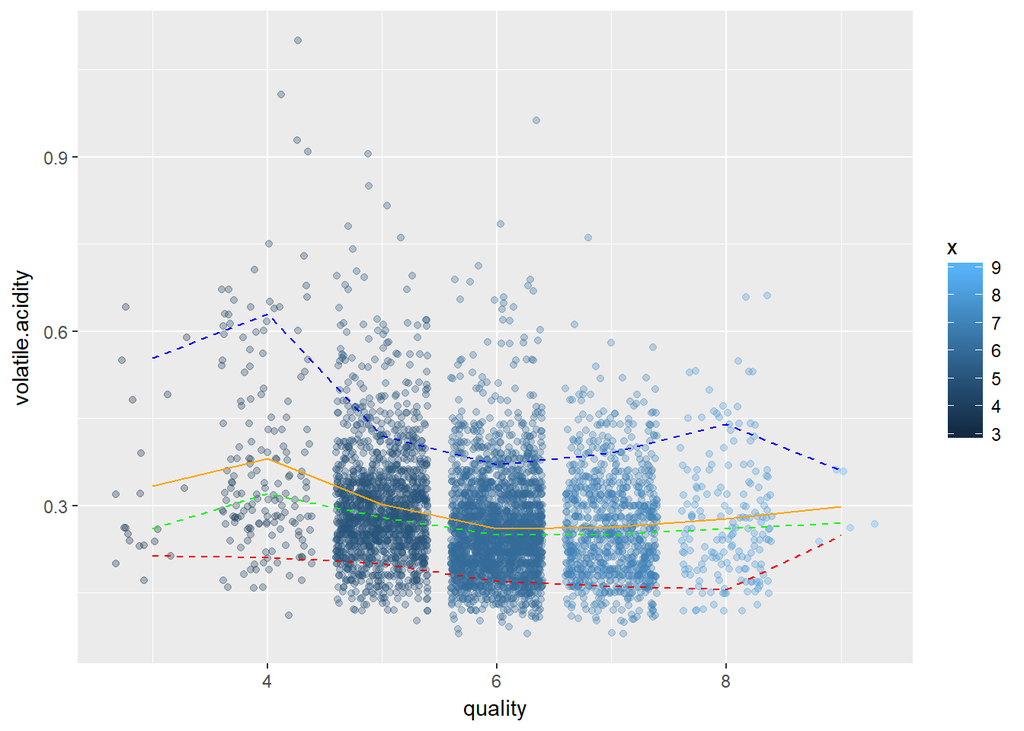

# 双变量分析

### 探讨你在这部分探究中观察到的一些关系。这些感兴趣的特性与数据集内其他特性有什么区别？

1. alcohol 与 density 强相关
2. fixed.acidity 对 pH 影响较大
3. alcohol 会对 quality 有较大影响

### 你是否观察到主要特性与其他特性之间的有趣关系？

硫酸盐在葡萄酒产中是一种用于产生二氧化硫的添加剂，经分析，硫酸盐与总二氧化硫，硫酸盐与游离二氧化硫之间相关系数并不高

### 你发现最强的关系是什么？

alcohol 与 density 强相关

# 多变量绘图选择

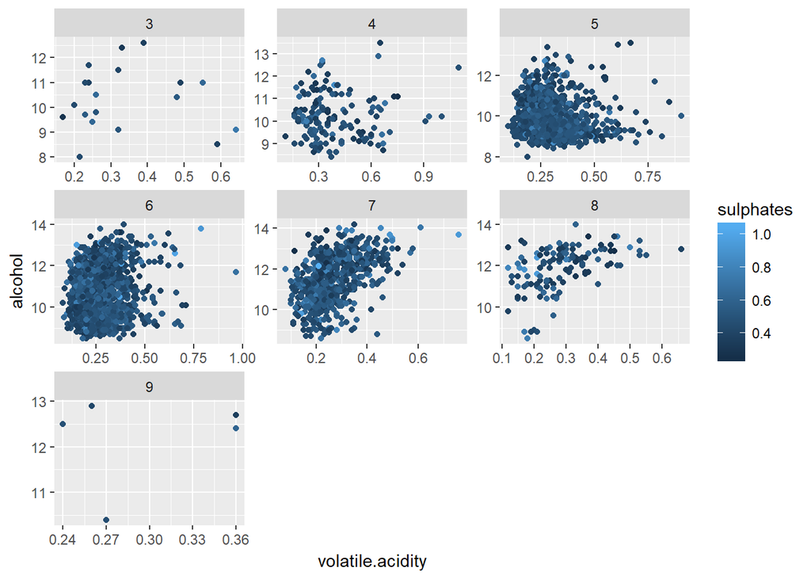

- quality 在区间[3,6]时明显集中在左下侧，从7开始向右上偏移。 sulphates 未知，将在下图进行具体分析

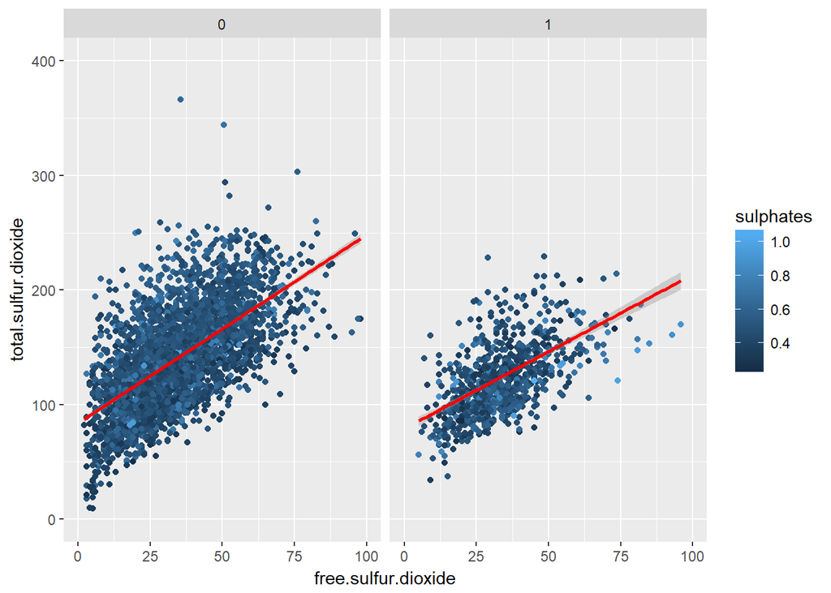

- 限定 x 与 y 轴过滤部分异常值后，free.sulfur.dioxide 与 total.sulfur.dioxide 分布在各数值的 premium 没有明显变化，sulphates 在品质较高中可以看出占比越来越高

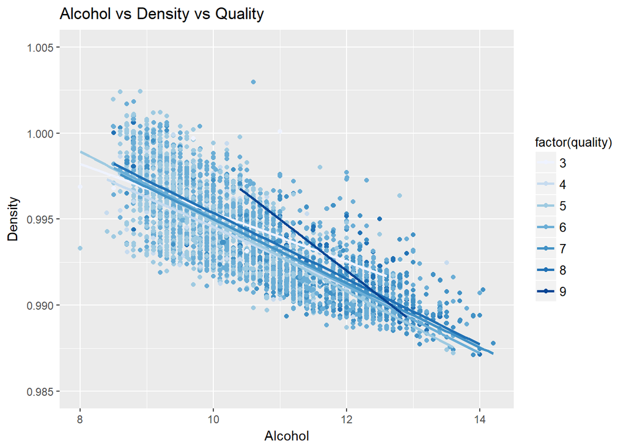

- density 与 alcohol 根据斜率可以看出明显负相关，alcohol 增大时 quality 高的出现的频率变大

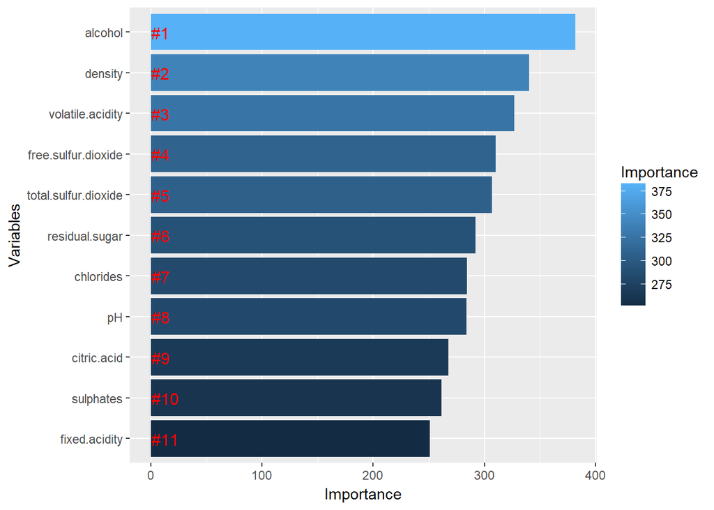

- 调用随机森林模型，将所有变量输入进行模拟，可以看到酒精对于 quality 权重最大。

# 多变量分析

### 探讨你在这部分探究中观察到的一些关系。通过观察感兴趣的特性，是否存在相互促进的特性？

酒精度数与密度高度负相关

### 选项：你是否创建过数据集的任何模型？讨论你模型的优缺点。

# 定稿图与总结

### 绘图一

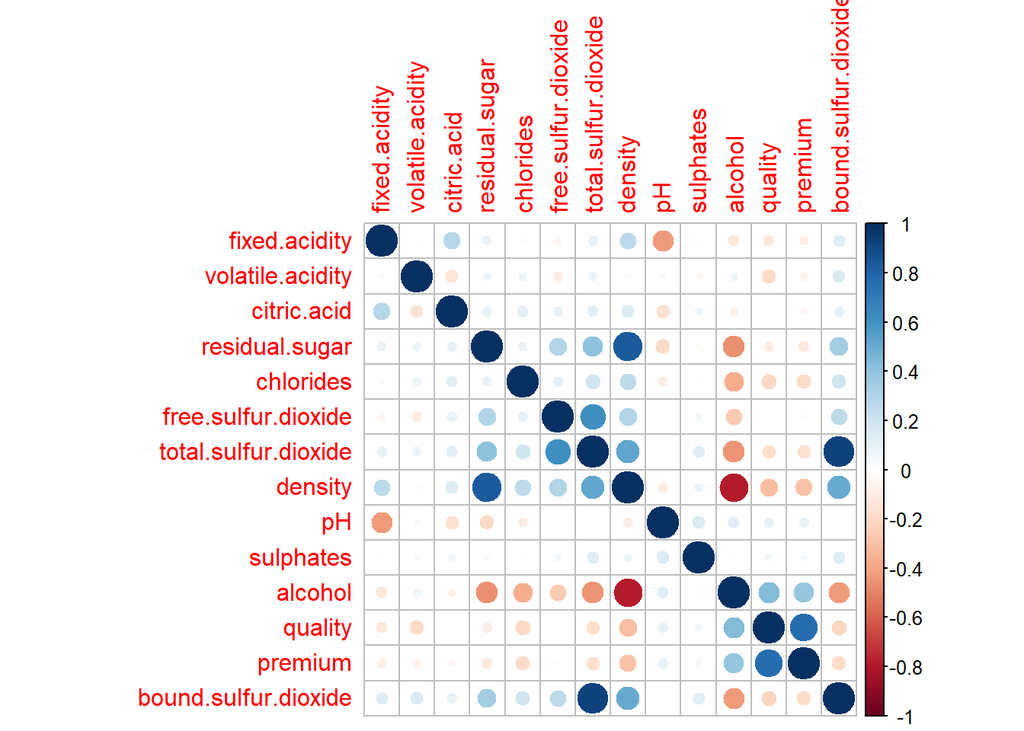

### 描述一

使用新的 package 轻松的获取了各变量之间的相关关系

### 绘图二

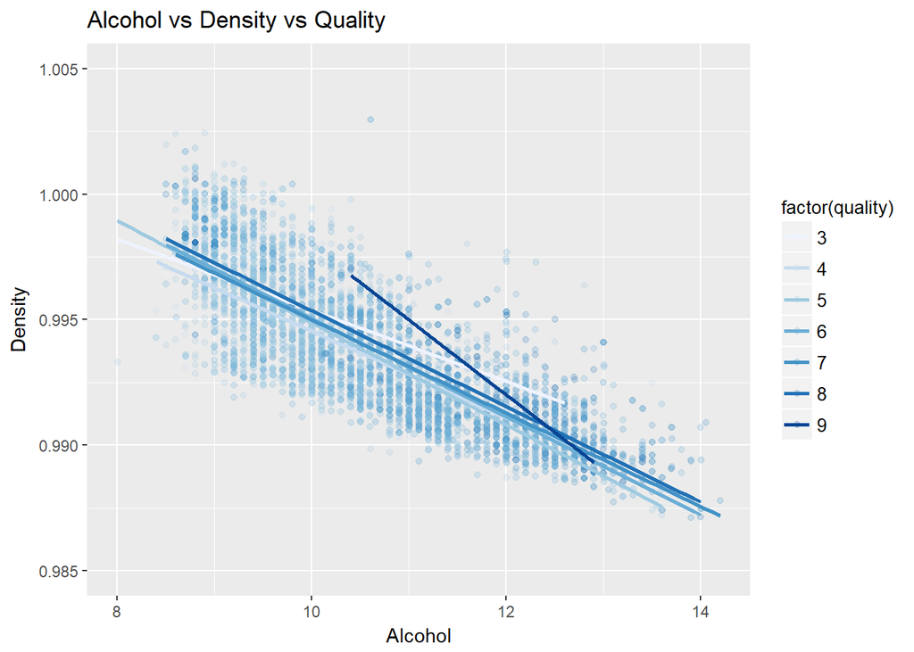

### 描述二

- 红酒品质越高，酒精度数越高
- 酒精度数越高，密度越低

### 绘图三

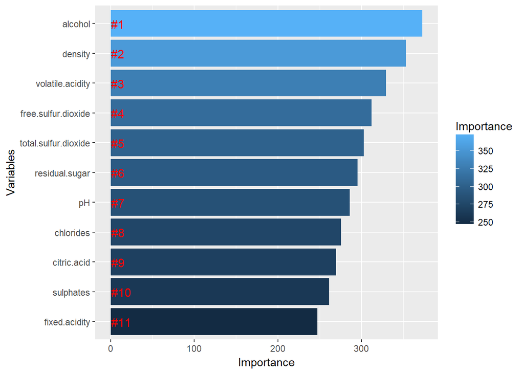

## 使用随机森林验证之前的结果

# 反思

作为非业内人士，对于此数据集除了酒精与浓度关系是常识外，其他一概不知，看了数据集的介绍也还是有点找不到方向。所以开头使用了矩阵图查看各变量之间的相关关系切入，根据这个来进行逐个分析。但用单变量、双变量及多变量通过相关关系分析酒的品质是如何成因的话有些片面，主要因为数据集的规模还不够大，并且 quality 为8与9的数据太少，所以新建了一个叫做 premium 的变量，囊括了quality 为7，8，9的数据，进行统合分析。之后通过随机森林模型对求证结果进行反推，发现了有很多不足，还需要进一步加强。如果有可能的话，将来会引进更多机器学习模型，对分析结果再审视一遍。